# Classification

## Name: Ryan Donaldson

## Date: 02/13/2023

### Summary

Linear models predict which category a given input belongs to by creating a linear decision to separate different data classes from each other. The strength of linear models is that they can be used with large datasets and are easy to visualize and implement. The weakness of linear models is that they assume a linear relationship between the features and the target variable.

Please click [here](https://www.kaggle.com/datasets/yasserh/uber-fares-dataset) to access the dataset used in this project.

#### Data Cleaning

Before exploring and visualizing data, let’s clean our dataset to make our overall linear regression model easier to work with as well as compiling informative graphs later on.

First, we will read the CSV and load the geosphere package so we can better work with latitude and longitude data that the columns will provide. We will also load the dplyr package to make column and row operations and mutations easier. We will load the e1071 package to build a Naive Bayes model and caret for useful distribution statistics.

```r
Uber <- read.csv("uber.csv", na.strings="NA", header=TRUE)
if(!require("geosphere")) {
  install.packages("geosphere")
  library("geosphere")
}
if(!require("dplyr")) {
  install.packages("dplyr")
  library("dplyr", warn.conflicts=FALSE)
}
if(!require("e1071")) {
  install.packages("e1071")
  library("e1071", warn.conflicts=FALSE)
}
if(!require("caret")) {
  install.packages("caret")
  library("caret", warn.conflicts=FALSE)
}
```

Let’s remove any rows which contain any latitude or longitude outliers.

```r
exclude_pickup_lon <- filter(Uber, pickup_longitude < -360
         | pickup_longitude > 360
         | pickup_longitude < -180
         | pickup_longitude > 180)
Uber <- anti_join(Uber, exclude_pickup_lon, by="key")

exclude_dropoff_lon <- filter(Uber, dropoff_longitude < -360
         | dropoff_longitude > 360
         | dropoff_longitude < -180
         | dropoff_longitude > 180)
Uber <- anti_join(Uber, exclude_dropoff_lon, by="key")

exclude_pickup_lat <- filter(Uber, pickup_latitude < -90
         | pickup_latitude > 90)
Uber <- anti_join(Uber, exclude_pickup_lat, by="key")

exclude_dropoff_lat <- filter(Uber, dropoff_latitude < -90
         | dropoff_latitude > 90)
Uber <- anti_join(Uber, exclude_dropoff_lat, by="key")
```

```r
print("Adding Distance column, please wait...")
```

```
## [1] "Adding Distance column, please wait..."
```

```r
Uber <- Uber %>% rowwise() %>%
  mutate(Distance_In_Km=distHaversine(c(pickup_longitude, pickup_latitude), c(dropoff_longitude, dropoff_latitude)))
print("Uber dataframe has been mutated")
```

```
## [1] "Uber dataframe has been mutated"
```

Now, we will divide the data into train and test sets using a 80/20 split.

```r
set.seed(1234)
i <- sample(1:nrow(Uber), nrow(Uber)*0.80,
replace=FALSE)
train <- Uber[i,]
test <- Uber[-i,]
```

#### Data Exploration

Next, we will run 5 R functions for data exploration of the data set using the training data. First, let’s run the str() function to get a look into the format of the data.

```r
str(train)
```

[output not shown]

[output cut: 59 more lines]

[output not shown]

Next, let’s gather an overall basic summary of each column of our training data.

```r
summary(train)
```

```
##        X                key             fare_amount     pickup_datetime
##  Min.   :       1   Length:159990      Min.   :-52.00   Length:159990
##  1st Qu.:13886062   Class :character   1st Qu.:  6.00   Class :character
##  Median :27763618   Mode  :character   Median :  8.50   Mode  :character
##  Mean   :27749116                      Mean   : 11.37
##  3rd Qu.:41600315                      3rd Qu.: 12.50
##  Max.   :55423567                      Max.   :499.00
##
##  pickup_longitude pickup_latitude  dropoff_longitude dropoff_latitude
##  Min.   :-93.82   Min.   :-74.01   Min.   :-75.42    Min.   :-74.02
##  1st Qu.:-73.99   1st Qu.: 40.73   1st Qu.:-73.99    1st Qu.: 40.73
##  Median :-73.98   Median : 40.75   Median :-73.98    Median : 40.75
##  Mean   :-72.51   Mean   : 39.93   Mean   :-72.52    Mean   : 39.93
##  3rd Qu.:-73.97   3rd Qu.: 40.77   3rd Qu.:-73.96    3rd Qu.: 40.77
##  Max.   : 40.81   Max.   : 48.02   Max.   : 40.83    Max.   : 45.03
##                                    NA's   :1         NA's   :1
##  passenger_count   Distance_In_Km
##  Min.   :  0.000   Min.   :      0
##  1st Qu.:  1.000   1st Qu.:   1216
##  Median :  1.000   Median :   2127
##  Mean   :  1.683   Mean   :  20083
##  3rd Qu.:  2.000   3rd Qu.:   3886
##  Max.   :208.000   Max.   :8792737
##                    NA's   :1
```

Our summary above tells us that exploring missing data is really not necessary considering the `dropoff_longitude` and `dropoff_latitude` columns each only contain 1 NA. So, first let’s just look at the first few rows.

```r
head(train)
```

| X | key | fare_amount | pickup_datetime | pickup_longitude | pickup_latitude | dropoff_longitude | dropoff_latitude | passenger_count | Distance_In_Km |
| --- | --- | --- | --- | --- | --- | --- | --- | --- | --- |
| 20105724 | 2010-03-04 08:53:30.0000006 | 9.70 | 2010-03-04 08:53:30 UTC | -73.83019 | 40.75939 | -73.84577 | 40.78410 | 1 | 3047.640 |
| 18896163 | 2014-10-12 03:30:41.0000002 | 17.00 | 2014-10-12 03:30:41 UTC | -73.98607 | 40.74586 | -73.91459 | 40.76596 | 1 | 6428.656 |
| 40414748 | 2010-07-16 07:57:00.00000030 | 34.27 | 2010-07-16 07:57:00 UTC | -73.86414 | 40.77031 | -73.97346 | 40.75783 | 1 | 9320.839 |
| 11607434 | 2013-09-14 09:27:00.000000131 | 7.50 | 2013-09-14 09:27:00 UTC | -74.00118 | 40.72761 | -74.00721 | 40.71160 | 1 | 1853.417 |
| 34954013 | 2014-06-20 06:19:25.0000003 | 13.50 | 2014-06-20 06:19:25 UTC | -73.95669 | 40.78641 | -74.00287 | 40.75617 | 1 | 5146.622 |
| 29082183 | 2011-03-27 17:09:00.000000162 | 49.80 | 2011-03-27 17:09:00 UTC | -73.98962 | 40.75751 | -73.98962 | 40.75751 | 3 | 0.000 |

Now, let’s look at the last few rows of our training data.

```r
tail(train)
```

| X | key | fare_amount | pickup_datetime | pickup_longitude | pickup_latitude | dropoff_longitude | dropoff_latitude | passenger_count | Distance_In_Km |
| --- | --- | --- | --- | --- | --- | --- | --- | --- | --- |
| 55251256 | 2014-08-20 23:51:55.0000002 | 32.83 | 2014-08-20 23:51:55 UTC | -73.98886 | 40.73654 | -73.85475 | 40.72572 | 1 | 11376.2551 |
| 9135184 | 2012-07-09 08:28:31.0000001 | 4.10 | 2012-07-09 08:28:31 UTC | -74.00158 | 40.74558 | -73.99456 | 40.74587 | 1 | 592.1685 |
| 38983892 | 2010-06-25 12:27:48.0000004 | 4.50 | 2010-06-25 12:27:48 UTC | -73.99045 | 40.72889 | -73.98841 | 40.73757 | 1 | 981.6313 |
| 17122458 | 2011-04-26 01:03:03.0000001 | 8.50 | 2011-04-26 01:03:03 UTC | -74.00525 | 40.72032 | -73.99022 | 40.75697 | 1 | 4272.2295 |
| 28892833 | 2012-06-06 15:12:44.0000001 | 31.30 | 2012-06-06 15:12:44 UTC | -73.87460 | 40.77408 | -73.98547 | 40.75883 | 2 | 9500.7780 |
| 37672342 | 2012-05-09 21:34:00.000000118 | 9.30 | 2012-05-09 21:34:00 UTC | 0.00000 | 0.00000 | 0.00000 | 0.00000 | 5 | 0.0000 |

```r
names(train)
```

```
##  [1] "X"                 "key"               "fare_amount"
##  [4] "pickup_datetime"   "pickup_longitude"  "pickup_latitude"
##  [7] "dropoff_longitude" "dropoff_latitude"  "passenger_count"
## [10] "Distance_In_Km"
```

#### Data Visualization

Let’s create some informative graphs based on this training data, particuarly distributions of various columns since we’re working with such a large dataset. First, let’s get a sense of the distribution of ride distances.

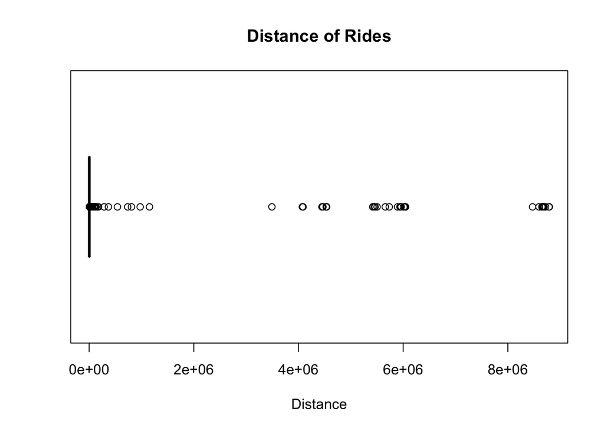

```r
boxplot(train$Distance_In_Km, col="slategray", horizontal=TRUE, xlab="Distance", main="Distance of Rides")
```

Next, let’s get a sense of the distribution of fare amounts.

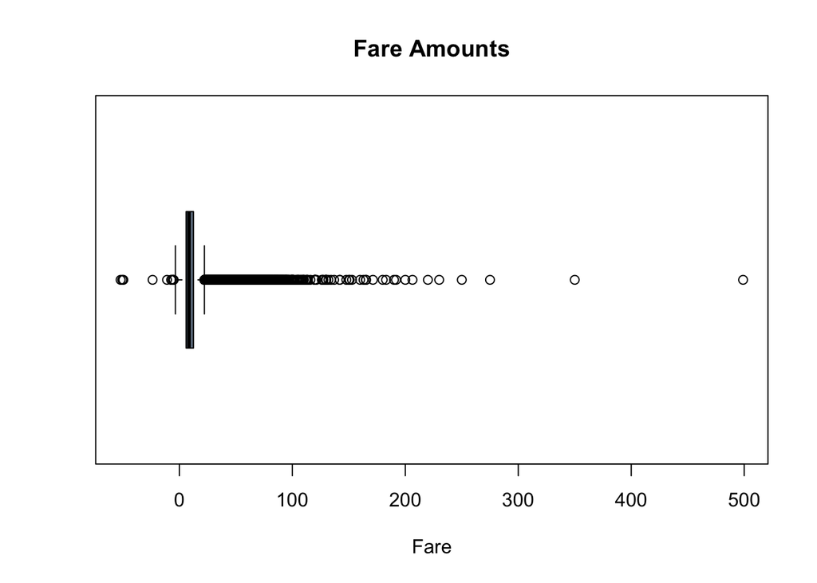

```r
boxplot(train$fare_amount, col="slategray", horizontal=TRUE, xlab="Fare", main="Fare Amounts")
```

Next, let’s get a sense of the distribution of passenger counts.

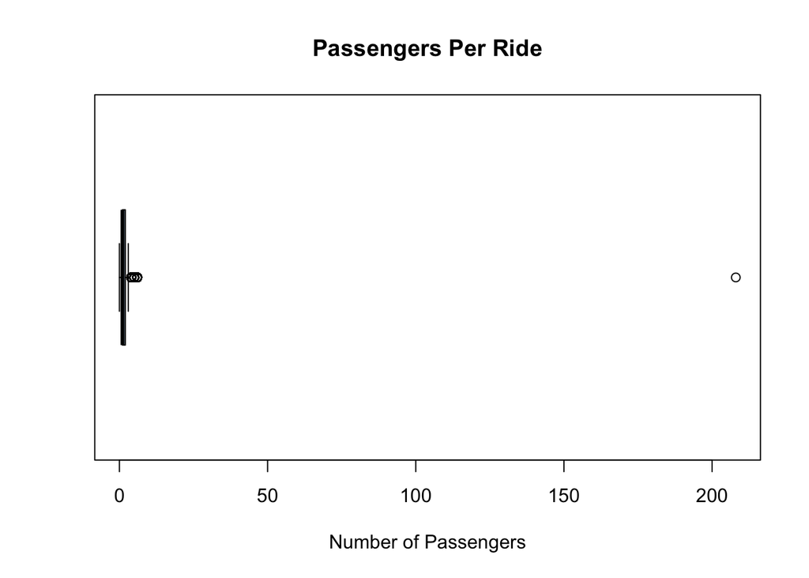

```r
boxplot(train$passenger_count, col="slategray", horizontal=TRUE, xlab="Number of Passengers", main="Passengers Per Ride")
```

After looking at the distribution among these columns, we’ve identified some outliers that would be best to remove.

Let’s further filter our Uber data set and then do a 80/20 split again.

```r
exclude_outliers <- filter(Uber, fare_amount < 0
         | fare_amount == 0
         | fare_amount > 60
         | passenger_count == 0
         | passenger_count > 6
         | Distance_In_Km == 0
         | Distance_In_Km > 80)
Uber <- anti_join(Uber, exclude_outliers, by="key")
```

Now, let’s divide the new filtered data into train and test sets using a 80/20 split.

```r
set.seed(1234)
i <- sample(1:nrow(Uber), nrow(Uber)*0.80,
replace=FALSE)
train <- Uber[i,]
test <- Uber[-i,]
```

Now that we’ve removed outliers, let’s see a histogram of the distance of rides.

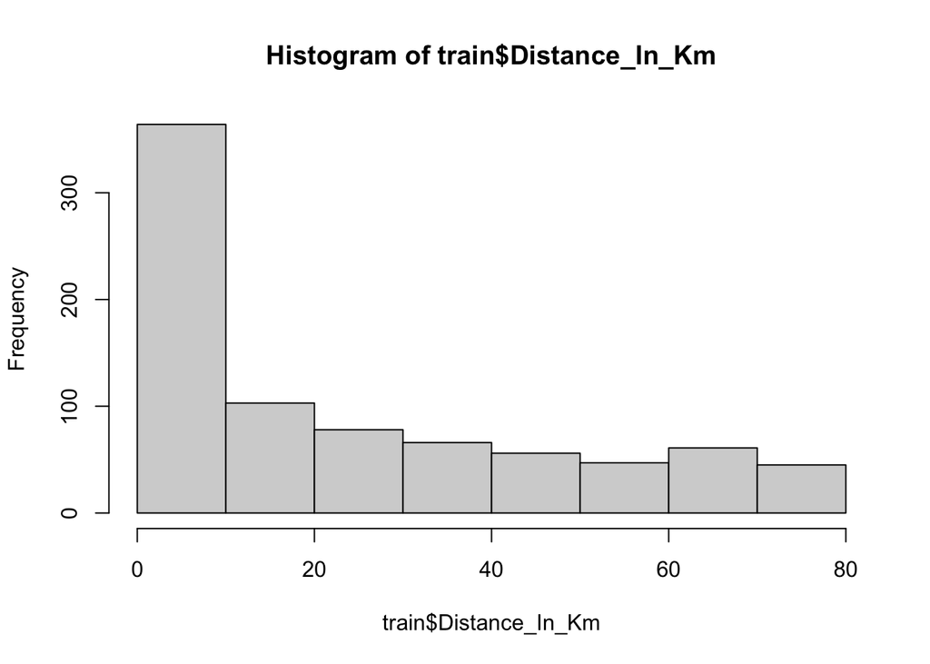

```r
hist(train$Distance_In_Km)
```

Now let’s see a histogram corresponding to fare amounts.

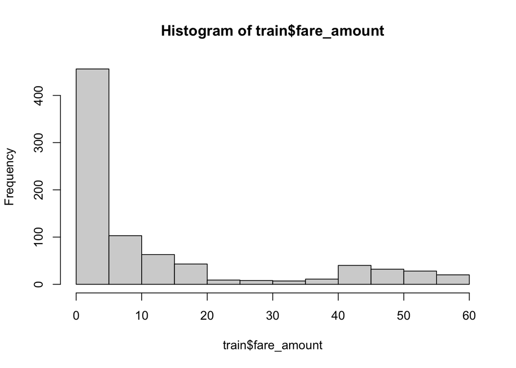

```r
hist(train$fare_amount)
```

```r
glm1 <- glm(as.factor(fare_amount)~Distance_In_Km, data=train, family=binomial)
summary(glm1)
```

```
##
## Call:
## glm(formula = as.factor(fare_amount) ~ Distance_In_Km, family = binomial,
##     data = train)
##
## Deviance Residuals:
##     Min       1Q   Median       3Q      Max
## -3.4480   0.0024   0.0249   0.0708   0.0899
##
## Coefficients:
##                Estimate Std. Error z value Pr(>|z|)
## (Intercept)      5.4955     1.2420   4.425 9.66e-06 ***
## Distance_In_Km   0.1751     0.2880   0.608    0.543
## ---
## Signif. codes:  0 '***' 0.001 '**' 0.01 '*' 0.05 '.' 0.1 ' ' 1
##
## (Dispersion parameter for binomial family taken to be 1)
##
##     Null deviance: 15.417  on 819  degrees of freedom
## Residual deviance: 13.886  on 818  degrees of freedom
## AIC: 17.886
##
## Number of Fisher Scoring iterations: 13
```

### Naive Bayes

Next, we will build a Naive Bayes model and output what the model learned.

```r
nb1 <- naiveBayes(fare_amount~Distance_In_Km, data=train)
nb1
```

```
##
## Naive Bayes Classifier for Discrete Predictors
##
## Call:
## naiveBayes.default(x = X, y = Y, laplace = laplace)
##
## A-priori probabilities:
## Y
##        0.01        0.11         2.5         2.9           3        3.25
## 0.001219512 0.001219512 0.365853659 0.025609756 0.042682927 0.001219512
##         3.3         3.4         3.5         3.7         3.8           4
## 0.017073171 0.001219512 0.018292683 0.013414634 0.001219512 0.004878049
##         4.1         4.5         4.9           5         5.1         5.3
## 0.010975610 0.036585366 0.007317073 0.007317073 0.001219512 0.007317073
##         5.5         5.7           6         6.1         6.2         6.3
## 0.003658537 0.008536585 0.002439024 0.002439024 0.001219512 0.001219512
##         6.5         6.9           7         7.3         7.5         7.7
## 0.020731707 0.006097561 0.004878049 0.003658537 0.003658537 0.006097561
##           8         8.1         8.2         8.5         8.6         8.9
## 0.004878049 0.008536585 0.001219512 0.008536585 0.001219512 0.004878049
##           9         9.3         9.5         9.6         9.7         9.8
## 0.004878049 0.003658537 0.004878049 0.001219512 0.002439024 0.001219512
##          10        10.1        10.2        10.3        10.5        10.9
## 0.004878049 0.003658537 0.001219512 0.001219512 0.007317073 0.001219512
##          11        11.3        11.5        11.7          12        12.1
## 0.003658537 0.007317073 0.001219512 0.002439024 0.003658537 0.007317073
##        12.5        12.9          13        13.3        13.5        13.8
## 0.003658537 0.002439024 0.002439024 0.001219512 0.003658537 0.001219512
##          14        14.1        14.5        14.6        14.9          15
## 0.003658537 0.003658537 0.004878049 0.001219512 0.003658537 0.004878049
##        15.5        15.7        15.9          16        16.5        16.9
## 0.003658537 0.001219512 0.001219512 0.001219512 0.004878049 0.002439024
##          17        17.3        17.5        17.9          18        18.1
## 0.003658537 0.001219512 0.007317073 0.001219512 0.001219512 0.001219512
##        18.9          19        19.3        19.7        19.8          20
## 0.001219512 0.001219512 0.001219512 0.001219512 0.001219512 0.015853659
##        20.5        20.9          23        23.7        24.5          25
## 0.002439024 0.002439024 0.001219512 0.001219512 0.001219512 0.002439024
##          27          28        28.5          29       29.07        29.3
## 0.001219512 0.001219512 0.001219512 0.001219512 0.001219512 0.001219512
```

[output cut: 145 more lines]

```
##   50.5  11.6526168  6.823416
##   51     3.3334793  1.130297
##   52    13.4893381 24.157310
##   53     7.8215156        NA
##   53.64 28.0296990        NA
##   54     5.2407085        NA
##   54.5   2.0926973  1.800871
##   55     0.5816101        NA
##   56.8  23.2305708 35.868620
##   57.33  2.2508692  2.738756
##   58     1.6710081  1.576015
##   58.5   0.4042437        NA
##   58.57 49.2121304        NA
##   59.5   6.8566415        NA
##   60    10.6152528 15.110639
```

### Prediction and Evaluation

First, let’s predict and evaluate on the test data of the logistic regression model.

```r
p1 <- predict(glm1, newdata=test, type="response")
pred <- ifelse(p1 > 0.5, 1, 0)
acc <- mean(p1==test$fare_amount)
print(paste("accuracy =", acc))
```

```
## [1] "accuracy = 0"
```

Now, let’s predict and evaluate on the test data of the Naive Bayes model.

```r
p2 <- predict(nb1, newdata=test, type="class")
acc2 <- mean(p2==test$fare_amount)
print(paste("accuracy =", acc2))
```

```
## [1] "accuracy = 0.344660194174757"
```

### Naive Bayes vs Logistic Regression

The strengths of Naive Bayes come from being useful for classification with a large dataset and independence between features. It works well with scattered data and can typically eliminate features that are not relevant to the prediction. However, its weaknesses fall under the fact that there might be a strong relationship between all the features, especially when there is not necessarily an independence between them. Logistic regression also finds its strengths in classification and a large dataset. It is easy to implement and visualize the impact of features on a target variable. However, there might only sometimes be a linear relationship among features. It only works well if there are a few outliers in the dataset so it may require further cleaning.

#### Sources

- https://dplyr.tidyverse.org/index.html
- https://www.rdocumentation.org/packages/geosphere/versions/1.5-18
- https://r4ds.had.co.nz/transform.html#transform
- https://stackoverflow.com/questions/32363998/function-to-calculate-geospatial-distance-between-two-points-lat-long-using-r
- https://stackoverflow.com/questions/40554592/geosphere-disthaversine-dplyr-error-wrong-length-for-vector-should-be-2
- https://www.youtube.com/watch?v=MHbzCs05Luo
- https://github.com/kjmazidi/Machine_Learning_2nd_edition/tree/master/Part_2_Linear_Models
- http://www.sthda.com/english/articles/36-classification-methods-essentials/151-logistic-regression-essentials-in-r/